# Tutorial for `MDRefine` - 3

##### ratio for a specific refinement

next, let's focus on a refinement **s2** and a single system **s**:

- plot original and new weights; compute their ratio and plot it;
- compute the Kish size and the relative Kish size;
- plot angle vs. ratio

```python
s2 = 'FFR'
s = 'AAAA'
```

```python
w0 = data.mol[s].weights
w1 = weights_new['E+FM+FF ref ff'][s]
w2 = weights_new['E+FM+FF ref'][s]

relS = np.sum(w2*np.log(w2/w1))
print(relS)

relS = np.sum(w1*np.log(w1/w0))
print(relS)

relS = np.sum(w2*np.log(w2/w0))
print(relS)
```

```
0.02183041903581102
0.346838610237152
0.37598970093184536
```

```python
s2 = 'E+FM+FF ref ff'
```

```
6006.955360944868
1.6930373856482768
```

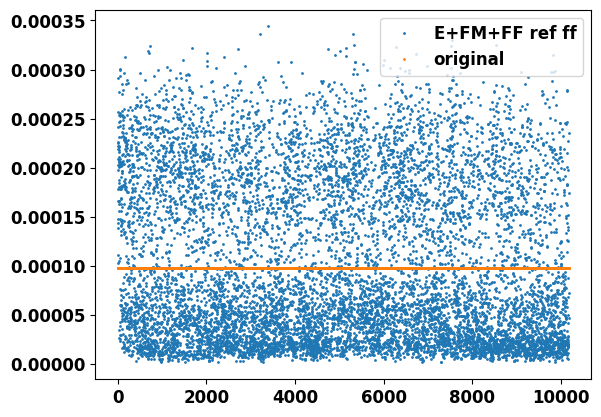

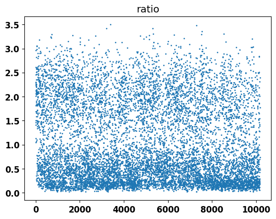

```python
plt.plot(weights_new[s2][s], '.', markersize=2, label=s2)
plt.plot(data.mol[s].weights, '.', markersize=2, label='original')
plt.legend()

plt.figure()
ratio = weights_new[s2][s]/data.mol[s].weights
# ratio = weights_new['E+FM+FF ref'][s]/weights_new['E+FM+FF ref ff'][s]
plt.plot(ratio, '.', markersize=2)
plt.title('ratio')
# plt.yscale('log')

Kish = 1/np.sum(weights_new[s2][s]**2)

print(Kish)
# print(np.exp(-Result.D_KL_alpha[s]))

rel_kish = np.sum(weights_new[s2][s]**2/data.mol[s].weights)
print(rel_kish)
```

```
6
```

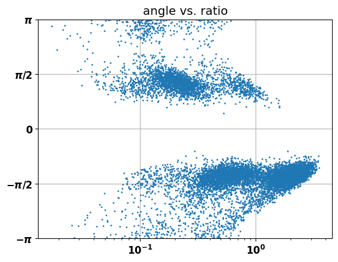

```python
length = len(data.mol[s].f.T)//2
print(length)

i = 0

angles = np.arcsin(data.mol[s].f[:, i])
wh = np.argwhere(data.mol[s].f[:, i + length] < 0)
angles[wh] = np.pi - angles[wh]
angles = np.mod(angles, 2*np.pi)

wh = np.argwhere((angles > np.pi) & (angles < 2*np.pi))
angles[wh] = angles[wh] - 2*np.pi

plt.plot(ratio, angles, '.', markersize=2)
plt.xscale('log')
plt.title('angle vs. ratio')
plt.ylim([-np.pi, np.pi])
plt.yticks([-np.pi, -np.pi/2, 0, np.pi/2, np.pi], ['$-\pi$', '$-\pi/2$', '0', '$\pi/2$', '$\pi$'])
plt.grid()
```

here it's evident that negative angles are favoured by the reweighting w.r.t. positive angles; if instead we look at the dihedral angles used in the forward model, there is not such a correlation

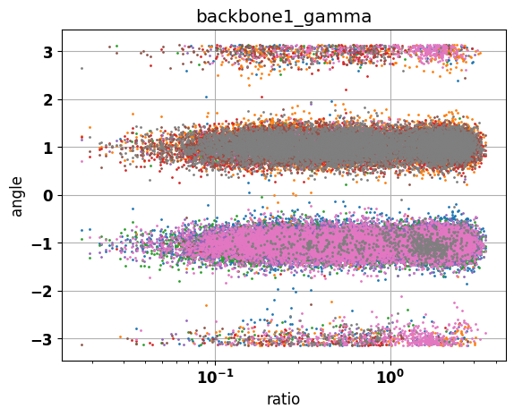

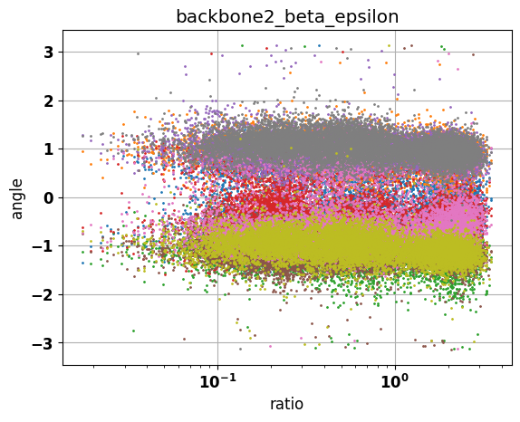

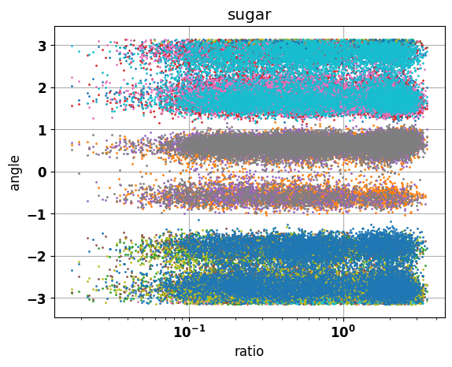

```python
for key in data.mol[s].forward_qs.keys():

    plt.figure()
    plt.title(key)

    length = len(data.mol[s].forward_qs[key].T)

    for i in range(length):
        angles = data.mol[s].forward_qs[key][:, i]
        plt.plot(ratio, angles, '.', markersize=2)

    plt.xscale('log')
    plt.xlabel('ratio')
    plt.ylabel('angle')
    plt.grid()
    plt.show()
```